# Session 5.2 Application Activity

This R notebook accompanies the [Session 5.2 application activity](http://www.globalhealthresearch.co/modules/mod6/s6-2/) for [Global Health Research: Designs and Methods](http://www.globalhealthresearch.co/). To get started, click the “Code” button in the top right corner of the screen and download the `Rmd` file. You have two options for running this file:

1. If you downloaded and installed R and RStudio, you can open this file with RStudio.
2. The easier option is to login to your ‘virtual’ RStudio environment on Duke’s server. Go [here](https://vm-manage.oit.duke.edu/), enter your credentials, and follow the `Docker` link to the option to launch RStudio. Once RStudio is running in your browser, go to the `Files` tab and `Upload` the `Rmd` file. Open it and clear all objects from the workspace (Session > Clear Workspace).

## Setup

This first code chunk will check to make sure you have all of the required packages.

```r
# packages
  list.of.packages <- c("plyr", "dplyr", "knitr", "blockTools",
                        "ggplot2")
  new.packages <- list.of.packages[!(list.of.packages %in%
                                     installed.packages()[,"Package"])]
  if(length(new.packages)) install.packages(new.packages)
  library(plyr)
  library(dplyr)
  library(knitr)
  library(blockTools)
  library(ggplot2)
# document setttings
  knitr::opts_chunk$set(results='hide')
# rounding functions
  rd0 <- function(y) sprintf("%.0f", round(y, 0))
  rd1 <- function(y) sprintf("%.1f", round(y, 1))
  rd2 <- function(y) sprintf("%.2f", round(y, 2))
  rd3 <- function(y) sprintf("%.3f", round(y, 3))
```

## Example

Let’s imagine that we are evaluating the impact of a new 10-session depression intervention for adults.

## Data

Let’s start by creating some fake baseline data. This dataset will have four variables: participant ID (`ID`), an indicator that the participant is female (`female`, coded `1` for female and `0` for male), participant age (`age`), and participant score on the Center for Epidemiological Studies-Depression (CES-D), a 20-item measure of depression. Responses are scored on a 4-point scale from “Rarely/None” (0) to “Most/Almost All” (3), so sum scores can range from 0 to 60. Higher scores represent more severe symptoms of depression. Everyone in this dataset has a score above 16 because that is an established cutoff for possible depression in this population.

```r
  set.seed(492)                                      # to make reproducible
  N <- 300                                           # sample size of 300
  dat <- data.frame(ID=seq(1, N, by=1),
                    female=sample(0:1,               # indicator for woman
                                  N,
                                  replace=TRUE,
                                  prob=c(.7, .3)),
                    age=sample(18:35,                # age between 18 and 35
                               N,
                               replace=TRUE),
                    cesdBase=sample(16:60,           # baseline CESD score
                                    N,
                                    replace=TRUE))
  head(dat)
```

|  | ID | female | age | cesdBase |
| --- | --- | --- | --- | --- |
| 1 | 1 | 1 | 21 | 35 |
| 2 | 2 | 0 | 23 | 28 |
| 3 | 3 | 0 | 20 | 57 |
| 4 | 4 | 0 | 23 | 59 |
| 5 | 5 | 0 | 32 | 24 |
| 6 | 6 | 0 | 22 | 53 |

(this table shows you the first 6 rows of the 300 observation dataset)

Q1. Determine the following:

1. What proportion of the sample is female?
2. What is the mean age?
3. What is the mean CESD score at baseline?

Try using `mean(dat$varname)`, replacing `varname` with `female`, `age`, and `cesdBase`.

## Random Assignment

Now let’s randomly assign these 300 participants to two study arms: standard of care and treatment.

```r
  dat$rand <- runif(N)                  # create random number between 0 and 1
  dat <- dat[order(dat$rand),]          # sort by random number
  dat$arm <- c(rep("control",N/2),      # assign first half to control
               rep("treatment",N/2))
```

Q2. How do the groups compare at baseline?

```r
  dat %>%
    group_by(arm) %>%
    summarize(count = n(),
              female = mean(female, na.rm = T),
              age = mean(age, na.rm = T),
              cesdBase = mean(cesdBase, na.rm = T))
```

| arm | count | female | age | cesdBase |
| --- | --- | --- | --- | --- |
| control | 150 | 0.22 | 25.61333 | 38.98000 |
| treatment | 150 | 0.28 | 26.61333 | 37.91333 |

Let’s randomize again to `arm2`, but this time blocking on some baseline variables.

```r
# block assignment
  block.out <- block(data = dat,
                     n.tr = 2,
                     id.vars ="ID",
                     algorithm="randGreedy",
                     block.vars = c("female", "age", "cesdBase"),
                     verbose=TRUE)
  assign.out <- assignment(block.out) # reports treatment assignment

# extract assignment details and merge with dat
  ID <- as.numeric(as.character(unlist(assign.out$assg[[1]]["Treatment 1"])))
  arm2 <- rep("control", length(ID))
  datC <- data.frame(cbind(ID, arm2))

  ID <- as.numeric(as.character(unlist(assign.out$assg[[1]]["Treatment 2"])))
  arm2 <- rep("treatment", length(ID))
  datT <- data.frame(cbind(ID, arm2))

  datTC <- rbind(datC, datT)
  dat <- merge(dat, datTC, by="ID")
  head(dat)
```

|  | ID | female | age | cesdBase | rand | arm | arm2 |
| --- | --- | --- | --- | --- | --- | --- | --- |
| 1 | 1 | 1 | 21 | 35 | 0.5105625 | control | treatment |
| 2 | 2 | 0 | 23 | 28 | 0.2979569 | control | treatment |
| 3 | 3 | 0 | 20 | 57 | 0.4546931 | control | control |
| 4 | 4 | 0 | 23 | 59 | 0.7934082 | treatment | treatment |
| 5 | 5 | 0 | 32 | 24 | 0.5011946 | control | treatment |
| 6 | 6 | 0 | 22 | 53 | 0.5215502 | control | control |

Q3. Now how do the groups compare at baseline? What does blocking accomplish?

```r
  dat %>%
    group_by(arm2) %>%
    summarize(count = n(),
              female = mean(female, na.rm = T),
              age = mean(age, na.rm = T),
              cesdBase = mean(cesdBase, na.rm = T))
```

| arm2 | count | female | age | cesdBase |
| --- | --- | --- | --- | --- |
| control | 149 | 0.2483221 | 26.13423 | 38.44295 |
| treatment | 151 | 0.2516556 | 26.09272 | 38.45033 |

We’ll use `arm2` as the assignment variable going forward. Now we can go ahead and simulate some mock endline data collected 3-months after the intervention completed.

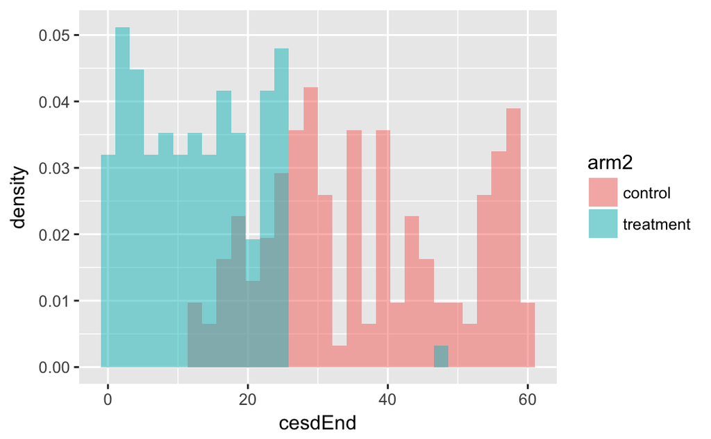

```r
  dat <- dat[order(dat$arm2),]
  dat$cesdEnd <- c(sample(12:60,
                          N/2,
                          replace=TRUE),
                   sample(0:25,
                          N/2,
                          replace=TRUE))
# plot endline scores by group
  ggplot(dat, aes(cesdEnd, fill = arm2)) +
    geom_histogram(alpha = 0.5, aes(y = ..density..), position = 'identity')
```

Q4. What does this histogram suggest?

## Attrition

### No attrition, full compliance

Let’s assume we had zero attrition and every participant complied with his or her treatment assignment. What was the outcome of the study?

```r
  m1 <- lm(cesdEnd ~ arm2 + female + age + cesdBase,
           data=dat)
  summary(m1)
```

Q5. What was the impact of the intervention?

As you read on, pay attention to the size of the estimate for `arm2treatment`. Larger effects are more negative in this case (we want to reduce depression severity). Smaller effects go toward zero.

### Sytematic attrition, intent-to-treat

What if we had 10% attrition, but attrition was more common in the treatment group, and the attritters in the treatment group were those with the highest depression scores at baseline.

```r
# 10% attrition, systematic
  set.seed(492)
  dat <- dat[order(dat$arm2, dat$cesdBase),]
  sam <- sample(0:1,
                N/2,
                replace=T,
                prob=c(0.95, .05))
  Nsam <- sum(sam)
  miss <- .1*N
  dat$att10s <- c(sam,
                  c(rep(0, 129),
                    rep(1, miss-Nsam)))
# LOCF for "missing" at endline
  dat$cesdEnd.att10s <- ifelse(dat$att10s==1,
                               dat$cesdBase,
                               dat$cesdEnd)
# re-run intent to treat analysis
  m3 <- lm(cesdEnd.att10s ~ arm2 + female + age + cesdBase,
           data=dat)
  summary(m3)
```

Q6. Are the results biased? If so, how? Why?

## Non-Compliance

### One-sided, per protocol

Now let’s imagine that we obtained endline data from everyone (i.e., no attrition), but some of the most depressed people in the treatment group did not complete the intervention. In other words, they weren’t treated. This is **one-sided non-compliance**.

Here’s a **per protocol** analysis where we drop these non-compliers.

```r
  dat$treated <- c(rep(0, N/2),
                   c(rep(1, 120),
                     rep(0, 30)))
# per protocol
  m4 <- lm(cesdEnd ~ arm2 + female + age + cesdBase,
           data=dat[(dat$arm2=="control" & dat$treated==0) |
                    (dat$arm2=="treatment" & dat$treated==1), ])
  summary(m4)
```

Q7. Are the results biased? If so, how? Why?

### One-sided, as treated

Here’s an **as treated** analysis where instead of dropping these non-compliers from the treatment group, we consider them to be part of the control group since they weren’t treated.

```r
# create new variable that reflects treatment received, not assigned
  dat$asTreated <- ifelse(dat$arm2=="control", "control",
                   ifelse(dat$arm2=="treatment" & dat$treated==1, "treatment",
                          "control"))
# assume that treatment group members not treated would not have improved
  dat$cesdEnd[dat$arm2=="treatment" & dat$treated==0] <-
    dat$cesdBase[dat$arm2=="treatment" & dat$treated==0]
# per protocol
  m5 <- lm(cesdEnd ~ asTreated + female + age + cesdBase,
           data=dat)
  summary(m5)
```

Q8. Are the results biased? If so, how? Why?